# Exploration of our data

We start by loading in the data packages we will use.

```r
library(dplyr); library(ggplot2)
library(RiPraksis)
data(kap6)
df <- kap6
```

# Univariate distributions

## Continuous variables

Summarizing continuous variables usually means looking at their average, but also their minimum, maximum values and their spread.

```r
summary(df$Skepsis)
```

```
##    Min. 1st Qu.  Median    Mean 3rd Qu.    Max.    NA's
##   0.000   4.000   5.000   5.009   6.000  10.000       5
```

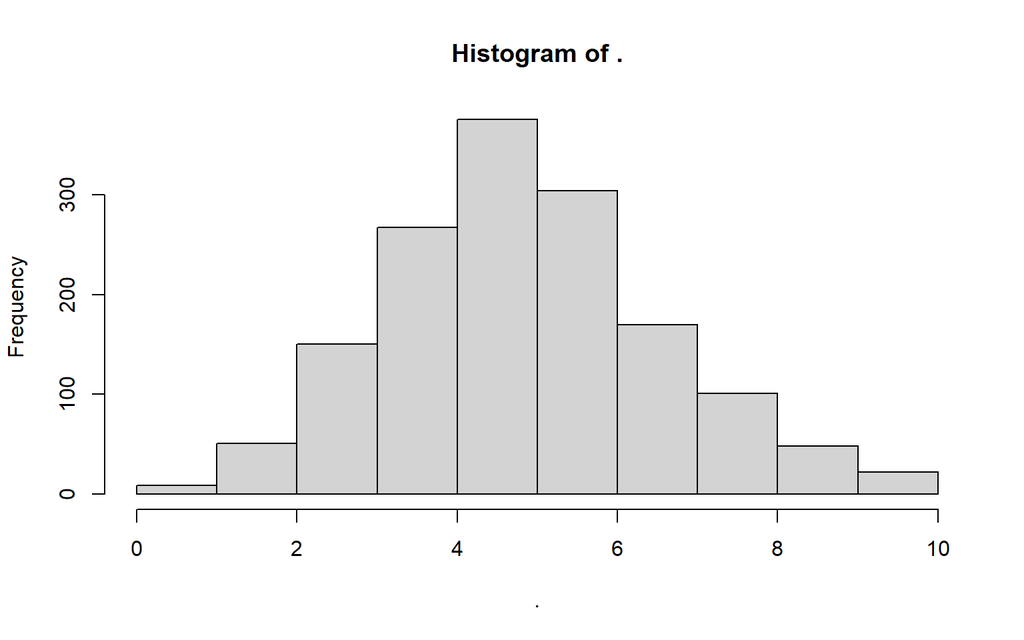

```r
df$Skepsis %>% hist
```

We can make it relative using a simple additional argument.

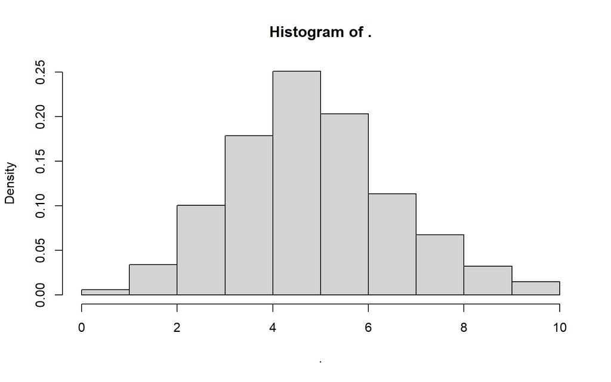

```r
df$Skepsis %>% hist(., probability = T)
```

## Categorical variables

We can explore categorical variables primarily by their frequency distribution.

Here, we are looking at what our respondents voted last election.

```r
df$Parti %>%
  table
```

```
## .
##                       Andet            Dansk Folkeparti
##                          17                         143
## Det Konservative Folkeparti        Det Radikale Venstre
##                          65                         134
##                Enhedslisten         Kristendemokraterne
##                          77                           8
##            Liberal Alliance          Socialdemokraterne
##                          48                         268
##     Socialistisk Folkeparti                     Venstre
##                         108                         311
```

In base, we need to make the frequency table first, then plot it using the appropriate function.

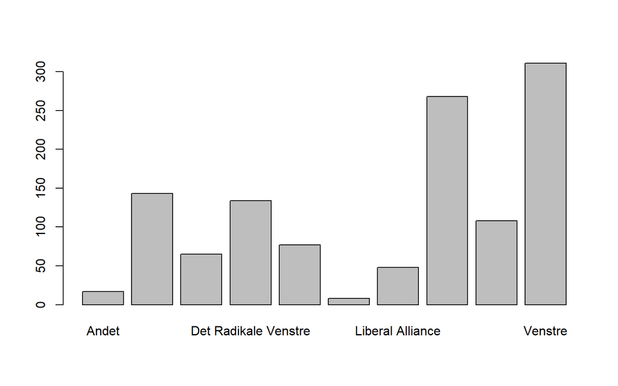

```r
df$Parti %>%
  table %>%
  barplot()
```

Usually, it is much more intuitive to check the relative distribution than the absolute. The function `prop.table()` does exactly that for us.

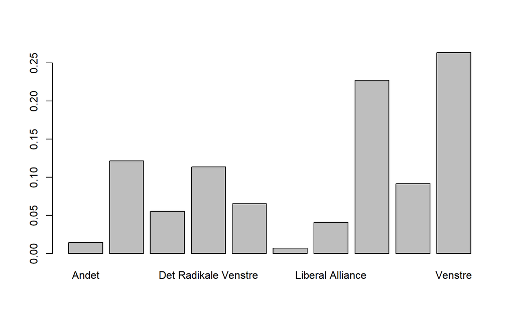

```r
df$Parti %>%
  #Frequency table
  table %>%
  #Relative distribution
  prop.table %>%
  #Barplot
  barplot()
```

> You can find more about data exploration in [this](https://ajsmit.github.io/Basic_stats/graphical-data-displays.html) tutorial, for example.

# Bivariate statistics

After exploring the variables separately, we usually check out their bivariate relationship. Once again, the choice of statistics depnds on the measurement level.

## Two continuous variables (+ ggplot2)

When we have two continuous variables, we can calculate their correlation using Pearsons R ($R^2$).

```r
cor(df$Indtaegt, df$Skepsis,
    use = "pairwise.complete.obs")
```

```
## [1] -0.1526337
```

The negative correlation is apparent, but what does it mean? Can we put it into plain English?

If we take the square of this correlation, we can interpret the result as a proportion of shared variation. Sometimes we’d interpret it as a causal relationship.

```r
cor(df$Indtaegt, df$Skepsis,
    use = "pairwise.complete.obs")^2
```

```
## [1] 0.02329706
```

We may say that 2 % of the variation in attitudes towards immigration is shared with (explained by?) income.

We can test the statistical significance between the two.

```r
cor.test(df$Indtaegt, df$Skepsis)
```

```
##
##  Pearson's product-moment correlation
##
## data:  df$Indtaegt and df$Skepsis
## t = -5.6155, df = 1322, p-value = 2.387e-08
## alternative hypothesis: true correlation is not equal to 0
## 95 percent confidence interval:
##  -0.20482310 -0.09957898
## sample estimates:
##        cor
## -0.1526337
```

Considering numbers in this way is really abstract though. The most intuitive way of exploring a correlation is through visuals. Let’s take a deep-dive into ggplot2.